# Text Analysis

Ankita Guha

January 29, 2019

Let’s load some of the libraries, that we might need to explore the datasets.

```r
#Installing Libraries
library(plyr)
library(tidytext)
library(janeaustenr)
library(stringr)
library(rJava) # qdap needs Java platform. Checkout how to install rJava.
library(qdap)
library(dplyr)
library(tm)
```

```r
library(wordcloud)
library(plotrix)
library(dendextend)
library(ggplot2)
library(ggthemes)
library(RWeka)
library(reshape2)
library(quanteda)
```

In the Next phase, let’s try to read our dataframe of interest and then take a sneakpeak of our dataframe containing the Customer’s Review along with the variables or the Columns of our interests.

```r
# Reading Data File
CustomerReview <- read.csv(file="Customer_Reviews.csv", header=TRUE, sep=",", stringsAsFactors = FALSE)

#Sneakpeak of the data
head(CustomerReview)
```

```
##                                                                                                                                                                                    What.does.DTE.do.well.to.earn.your.satisfaction.
## 1                                                                                                                                                                             They are helping the environment with wind and solar.
## 2 Provides quality power and responsive primary service representatives when we have a problem. Energy efficiency program is outstanding. Having a responsive account manager who understands our business and needs is a plus too.
## 3                                                                     Customer service has always been helpful and any issues have been fixed fairly quickly. Website is convienent and efforts to helo energy efficeiny arr great.
## 4                                                                                                                                  Energy efficiency incentives are nice, would be helpful if the greenhouse incentives were higher
## 5       The best way in my opinion is DTE provides ways to use less energy, which is counter-intuitive to a company which makes $ from consumers using energy.  Still not on board why you do that, but thanks for the suggestions.
## 6
##                                                                         What.does.DTE.need.to.improve.other.than.price.to.earn.your.sat.
## 1
## 2
## 3
## 4
## 5
## 6 Savings - assist with home solar cost and power buy back from home owners. Free install of electric vehicle charging stations in homes
```

```r
#Columns of Interest for Analysis
names(CustomerReview)
```

```
## [1] "What.does.DTE.do.well.to.earn.your.satisfaction."
## [2] "What.does.DTE.need.to.improve.other.than.price.to.earn.your.sat."
```

Since the Column names are little bigger, for the sake of analysis let’s try to accronym them for faster and easier data fetching.

```r
#Changing Column "What.does.DTE.do.well.to.earn.your.satisfaction.": First Column
colnames(CustomerReview)[which(names(CustomerReview) == "What.does.DTE.do.well.to.earn.your.satisfaction.")] <- "EarnSatisfaction"

#Changing Column "What.does.DTE.need.to.improve.other.than.price.to.earn.your.sat.": Second Column
colnames(CustomerReview)[which(names(CustomerReview) == "What.does.DTE.need.to.improve.other.than.price.to.earn.your.sat.")] <- "ImproveSatisfaction"
```

#### Step 1:

### Text Extraction

The next goal is to convert the text contained within the above Columns to data frame for ease of analysis.It is required to be converted into a collection of text documents or **corpus** named as **corpus_review**. Let’s ensure that we have the Corpus for both the columns indicating these two parameters: 1) “What.does.DTE.do.well.to.earn.your.satisfaction.”: Earnsatisfaction 2) “What.does.DTE.need.to.improve.other.than.price.to.earn.your.sat.”: ImproveSatisfaction

```r
## Make a vector source and a corpus for both the Columns containing the Customer Satisfaction Data
#Column 1: EarnSatisfaction
corpus_review1 <- Corpus(VectorSource(CustomerReview$EarnSatisfaction))

#Column 2: ImproveSatisfaction
corpus_review2 <- Corpus(VectorSource(CustomerReview$ImproveSatisfaction))
```

#### Step 2:

### Text Pre-processing

In this case, we are using the Bag of Words approach for the purpose of Textual Analysis, whereby based on the frequencies of the appearence of words we could analyze the sentiment associated with certain reviews as provided by the Customer. The DTM (Document Term Matrix) can help to identify the frequency of term occuring in a collection of documents. In a DTM, rows correspond to documents in the collection and columns correspond to terms.

Both the DTM and TDM (Term Document Matrix) must be cleaned and represent the core set of relevant words, thereby necessitating the need of pre-processing activities to be performed in the corpus.

## i) Conversion to Lower Case

```r
#Converting 1st Column to Lowercase: Converting corpus_review1
corpus_review1<-tm_map(corpus_review1, tolower)
#Converting 2nd Column to Lowercase: Converting corpus_review2
corpus_review2<-tm_map(corpus_review2, tolower)
```

## ii) Remove Punctuation

```r
#Removing Punctuation from 1st & 2nd Column
corpus_review1<-tm_map(corpus_review1, removePunctuation)
corpus_review2<-tm_map(corpus_review2, removePunctuation)
```

## iii) Remove Stopwords & Remove Numbers

### Lists of Standard English Stopwards

These words will be removed from both the Corpuses.

```r
stopwords("en")
```

```
##   [1] "i"          "me"         "my"         "myself"     "we"
##   [6] "our"        "ours"       "ourselves"  "you"        "your"
##  [11] "yours"      "yourself"   "yourselves" "he"         "him"
##  [16] "his"        "himself"    "she"        "her"        "hers"
##  [21] "herself"    "it"         "its"        "itself"     "they"
##  [26] "them"       "their"      "theirs"     "themselves" "what"
##  [31] "which"      "who"        "whom"       "this"       "that"
##  [36] "these"      "those"      "am"         "is"         "are"
##  [41] "was"        "were"       "be"         "been"       "being"
##  [46] "have"       "has"        "had"        "having"     "do"
##  [51] "does"       "did"        "doing"      "would"      "should"
##  [56] "could"      "ought"      "i'm"        "you're"     "he's"
##  [61] "she's"      "it's"       "we're"      "they're"    "i've"
##  [66] "you've"     "we've"      "they've"    "i'd"        "you'd"
##  [71] "he'd"       "she'd"      "we'd"       "they'd"     "i'll"
```

[output cut: 20 more lines]

That means removing the Prepositions, Conjunctions, Pronouns etc so as to remove the connecting words, else these connecting words would appear as some of the most frequently used words in the reviews of the Customer.

```r
#Remove stopwords from 1st & 2nd Column
corpus_review1<-tm_map(corpus_review1, removeWords, stopwords("english"))
corpus_review2<-tm_map(corpus_review2, removeWords, stopwords("english"))
#Remove Numbers from 1st & 2nd Column
corpus_review1<-tm_map(corpus_review1, removeNumbers)
corpus_review2<-tm_map(corpus_review2, removeNumbers)
```

## iv) Remove context specific stop words

```r
#Remove context specific words from 1st & 2nd Column
corpus_review1<-tm_map(corpus_review1, removeWords,c("dte", "company", "energy", "i", "we", "provide", "gas", "electri*", "bill*"))
corpus_review2<-tm_map(corpus_review2, removeWords,c("dte", "company", "energy", "i", "we", "provide", "gas", "electri*", "dont", "like", "bill"))
```

## v) Stemming Words

By this process of stemming, the derived words are essentially reduced to their word stem.

```r
# Stem document from 1st & 2nd Column
corpus_review1<-tm_map(corpus_review1, stemDocument)
corpus_review2<-tm_map(corpus_review2, stemDocument)
```

Okay, now that we have accomplished some levels of data cleaning. Let’s try to see some of the data in our Corpus now.

```r
##Viewing the corpus content for 1st Column
corpus_review1[[8]][1]
```

```
## $content
## [1] "applianc repair program ampl rebat save applianc"
```

```r
corpus_review1[[4]][1]
```

```
## $content
## [1] "effici incent nice help greenhous incent higher"
```

```r
##Viewing the corpus content for 2nd Column
corpus_review2[[6]][1]
```

```
## $content
## [1] "save assist home solar cost power buy back home owner free instal electr vehicl charg station home"
```

```r
corpus_review2[[21]][1]
```

```
## $content
## [1] "let senior free program can help thing get hous insul window replacementand free roof replac everyth els benefit"
```

#### Step 3:

### Exploratory Text Analysis

Let’s next identify the most frequently used words in overall Customers Review, for Column 1. ##For Column 1: What.does.DTE.do.well.to.earn.your.satisfaction.

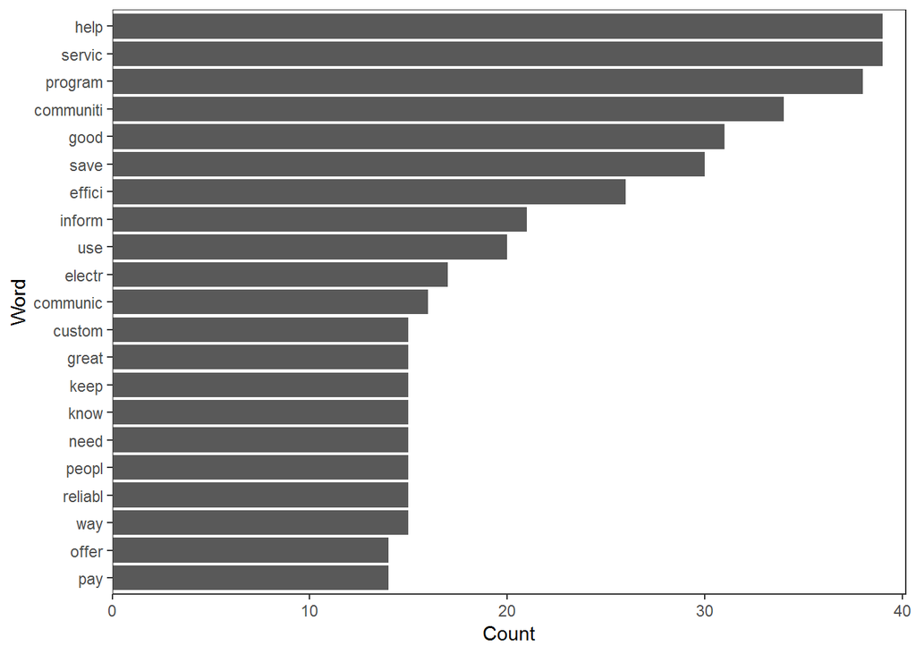

```r
#Find the 20 most frequent terms: term count
term_count1 <- freq_terms(corpus_review1, 20)

# Plot 20 most frequent terms
plot(term_count1)
```

Let’s next identify the most frequently used words in overall Customers Review, for Column 2. ##For Column 2: What.does.DTE.need.to.improve.other.than.price.to.earn.your.sat.

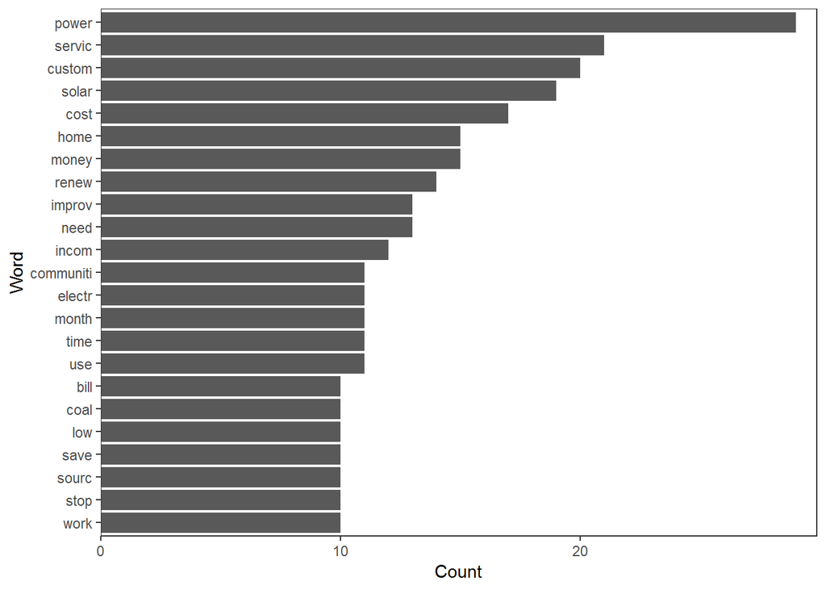

```r
#Find the 20 most frequent terms: term count
term_count2 <- freq_terms(corpus_review2, 20)

# Plot 20 most frequent terms
plot(term_count2)
```

#### Step 4: Create DTM & TDM from corpus

This decides the Document Term Matrix that can help to identify the frequency of terms occuring in the corpuses. In a DTM, Rows correspond to Documents and Columns corresponds to Terms. The TDM is a transpose of DTM.

```r
review_dtm1 <- DocumentTermMatrix(corpus_review1)
review_tdm1 <- TermDocumentMatrix(corpus_review1)

review_dtm2 <- DocumentTermMatrix(corpus_review2)
review_tdm2 <- TermDocumentMatrix(corpus_review2)
```

Let’s use the TDM to identify the frequent terms, by converting them to matrix

```r
# Convert TDM to matrix
review_m1 <- as.matrix(review_tdm1)
review_m2 <- as.matrix(review_tdm2)
# Sum rows and frequency data frame
review_term_freq1 <- rowSums(review_m1)
review_term_freq2 <- rowSums(review_m2)
# Sort term_frequency in descending order
review_term_freq1 <- sort(review_term_freq1, decreasing = T)
review_term_freq2 <- sort(review_term_freq2, decreasing = T)
# View the top 10 most common words
review_term_freq1[1:10]
```

```
##      help    servic   program communiti      good      save    effici
##        40        39        38        34        31        30        26
##    inform       use    electr
##        21        20        17
```

```r
review_term_freq2[1:10]
```

```
##  power servic  solar custom   cost   home  money  renew   need improv
##     29     21     19     19     17     15     15     14     13     12
```

#### Step 5: Visualization

### Plots

Let’s visualize these tokens of words appearing in the reviews and try to get an idea of what’s mostly appearing in the reviews. ## Column 1: What.does.DTE.do.well.to.earn.your.satisfaction.

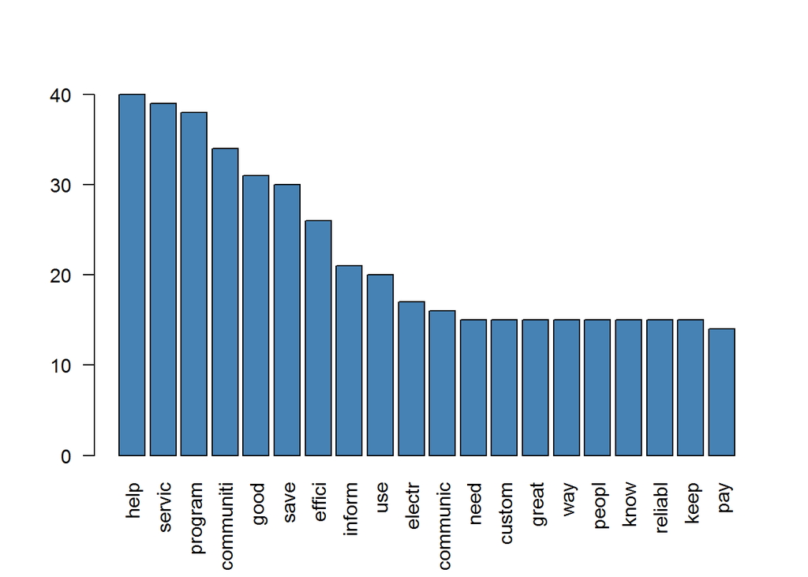

```r
# Plot a barchart of the 20 most common words
barplot(review_term_freq1[1:20], col = "steel blue", las = 2)
```

## Column 2: What.does.DTE.need.to.improve.other.than.price.to.earn.your.sat.

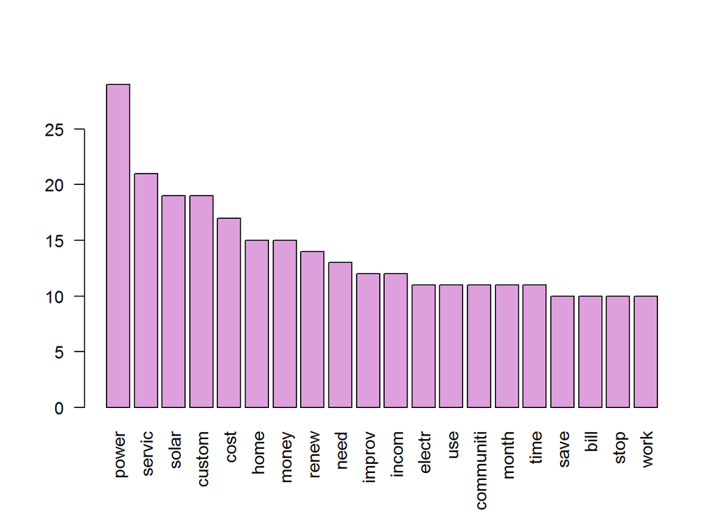

```r
# Plot a barchart of the 20 most common words
barplot(review_term_freq2[1:20], col = "plum", las = 2)
```

### Word Clouds

A much more interesting and common ways of visualizing the frequencies of the words apperaing across each of the documents is by creatung word cloud. This word cloud varies the size of the words based on the frequency of the appearence of each word.

## For Column 1: What.does.DTE.do.well.to.earn.your.satisfaction.

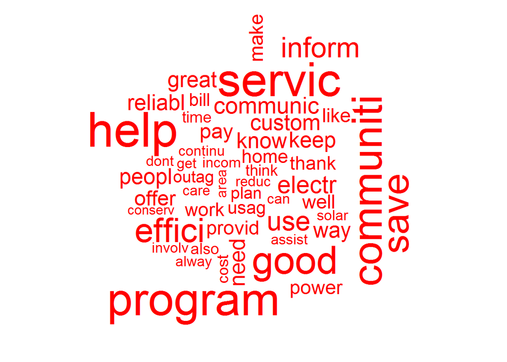

```r
review_word_freq1 <- data.frame(term = names(review_term_freq1),
  num = review_term_freq1)
# Create a wordcloud for the values in word_freqs
wordcloud(review_word_freq1$term, review_word_freq1$num,
  max.words = 50, colors = "red")
```

## For Column 2: What.does.DTE.need.to.improve.other.than.price.to.earn.your.sat.

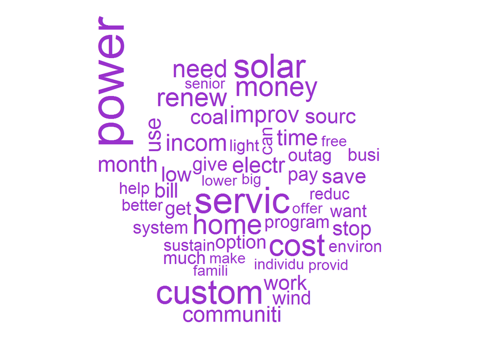

```r
review_word_freq2 <- data.frame(term = names(review_term_freq2),
  num = review_term_freq2)
# Create a wordcloud for the values in word_freqs
wordcloud(review_word_freq2$term, review_word_freq2$num,
  max.words = 50, colors = "darkorchid")
```

Let’s try to distinguish between the more frequent and less frequent words, appearing in both the Columns. ## For Column1: What.does.DTE.do.well.to.earn.your.satisfaction.

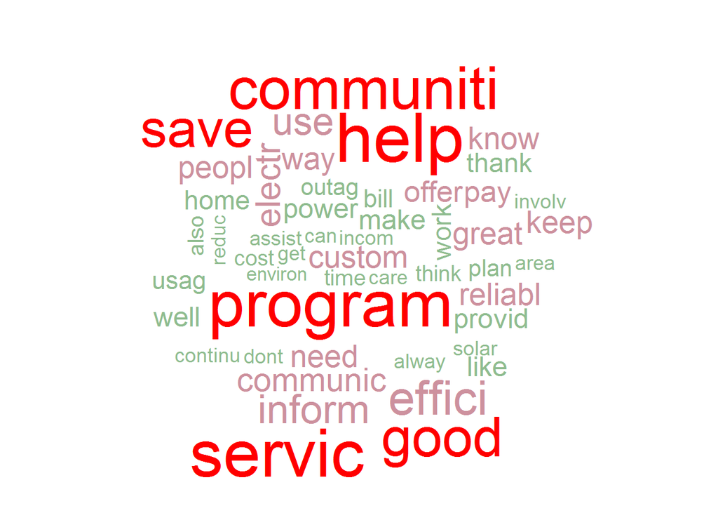

```r
# Print the word cloud with the specified colors
wordcloud(review_word_freq1$term, review_word_freq1$num,
  max.words = 50, colors = c("darkseagreen","pink3","red"))
```

## For Column2: What.does.DTE.need.to.improve.other.than.price.to.earn.your.sat.

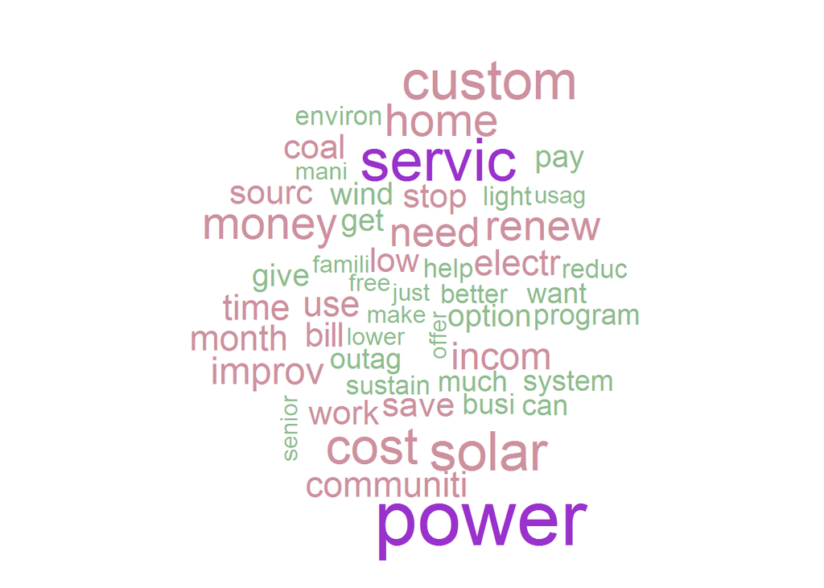

```r
# Print the word cloud with the specified colors
wordcloud(review_word_freq2$term, review_word_freq2$num,
  max.words = 50, colors = c("darkseagreen","pink3","darkorchid"))
```

#### Step 6: Comparing the Corpus

Now, that we have an idea on what all words have appeared mostly across both the survey questions, we can now deep dive to check for words that are appearing in both the two corpuses. For this purpose we need to find the commonality of words between the 2 corpuses (asking two different questions) and plot them in one shared wordcloud.

Next, we will check and compare the dissimilar words shared between the 2 corpuses.

```r
#Taking Up each Question to Paste into a seperate Corpora
all_EarnSatisfaction <- paste(CustomerReview$EarnSatisfaction, collapse = "")
all_ImproveSatisfaction <- paste(CustomerReview$ImproveSatisfaction, collapse = "")

#Combining Corpora
all_combine <- c(all_EarnSatisfaction, all_ImproveSatisfaction)

#Creating a new Corpus for the Combined Corpuses
corpus_review_all=Corpus(VectorSource(all_combine))
```

## Preprocessing

Now, that we have both the corpuses, let’s try to remove the punctuations and the stop words from our combined corpuses for the sake of text preprocessing.

```r
#Convert to lower-case
corpus_review_all=tm_map(corpus_review_all, tolower)
#Removing punctuation
corpus_review_all=tm_map(corpus_review_all, removePunctuation)
#Removing Stopwords
corpus_review_all=tm_map(corpus_review_all, removeWords, stopwords("english"))
corpus_review_all=tm_map(corpus_review_all, removeWords,c("dte", "company", "energy", "i", "we", "provide", "gas", "electri*", "dont", "like", "bill"))
#Stemming Documents
corpus_review_all=tm_map(corpus_review_all, stemDocument)
```

```r
review_tdm_all <- TermDocumentMatrix(corpus_review_all)
all_m=as.matrix(review_tdm_all)
colnames(all_m)=c("EarnSatisfaction", "ImproveSatisfaction")

#Sum rows and frequency data frame
review_term_freq_all <- rowSums(all_m)
review_word_freq_all <- data.frame(term=names(review_term_freq_all), num = review_term_freq_all)


#Word Frequency for all Words
#term_countall <- freq_terms(corpus_review_all, 20)
#plot(term_countall)
```

## Commonality Word Cloud

This word cloud shows the combined frequency of words apperaing in both of the corpuses. In other words this Cloud helps to understand the words that are occuring in both of the Columns that ask the questions: **1. What does DTE do well to earn your satisfaction?** and **2. What does DTE need to improve other than price to earn your satisfaction?**

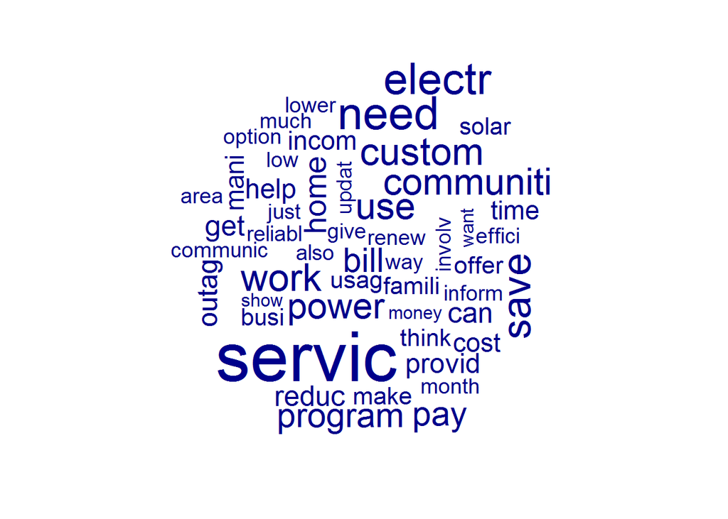

```r
#Make commonality cloud
commonality.cloud(all_m,
                  colors = "darkblue",
                  max.words = 50)
```

## Comparison Word Cloud

The comparison cloud on the other hand will identify dissimilar words used between the 2 corpora, with two different questions asked to the Customers. The demarcation gives an clear indication if the maximum words or sentiments that are appearing in max in these two questions so asked to DTE’s Customers.

**1. EarnSatisfaction: What does DTE do well to earn your satisfaction?** Clearly now we know, how DTE has been earning customer satisfaction by looking at the words that are appearing at a maximum frequency within each corpora as shown in the combined Word Cloud below, indicating the Questions so asked to them.

**2. ImproveSatisfaction: What does DTE need to improve other than price to earn your sat?** In terms of the Question so asked to our Customers that how we can improve our performance other than price, to earn Customer satisfaction we can check out the Word cloud in clear dimarcation indicating the maximum sentiments/words expressed by our Customers while answering to this question.

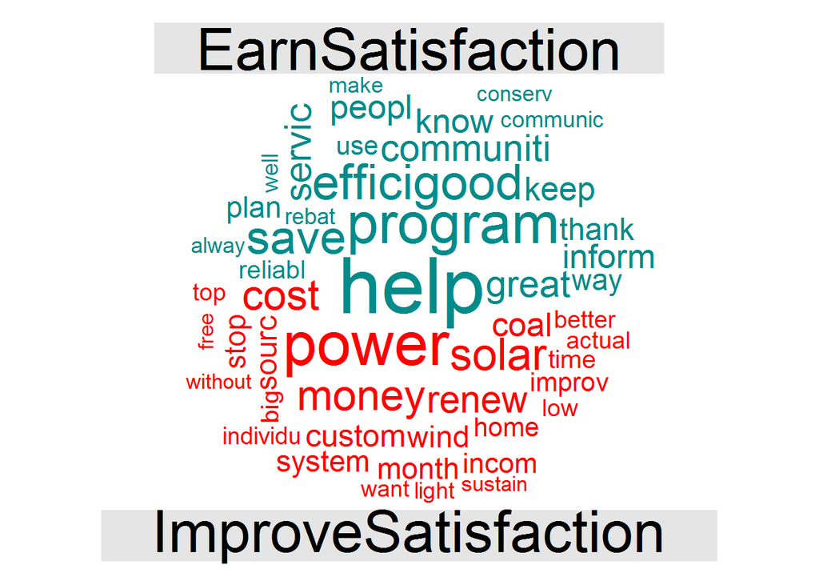

```r
# Create comparison cloud
comparison.cloud(all_m,
                 colors = c("darkcyan", "red"),
                 max.words = 50)
```

## Polarized Tag Plot

A polarized tag plot is an improved version of the commonality cloud. It determines the frequency of a term used in both the corpora under comparison. The difference in frequencies of common words might be insightful in many cases. For this plot, the plotrix package is loaded. First a matrix is created with all the common words using a subset to ensure that it contains only words occurring in both the classes. The matrix then has another column for the absolute difference between both the corpora for each word and the plot is made.

```r
#Identify terms shared by both documents
common_words <- subset(all_m, all_m[, 1] > 0 & all_m[, 2] > 0)

#Calculate common words and difference
difference <- abs(common_words[, 1] - common_words[, 2])
common_words <- cbind(common_words, difference)
common_words <- common_words[order(common_words[, 3],
                                   decreasing = T), ]
head(common_words)
```

```
##         EarnSatisfaction ImproveSatisfaction difference
## help                  39                   6         33
## program               32                   8         24
## save                  30                  10         20
## effici                23                   4         19
## good                  22                   3         19
## servic                37                  19         18
```

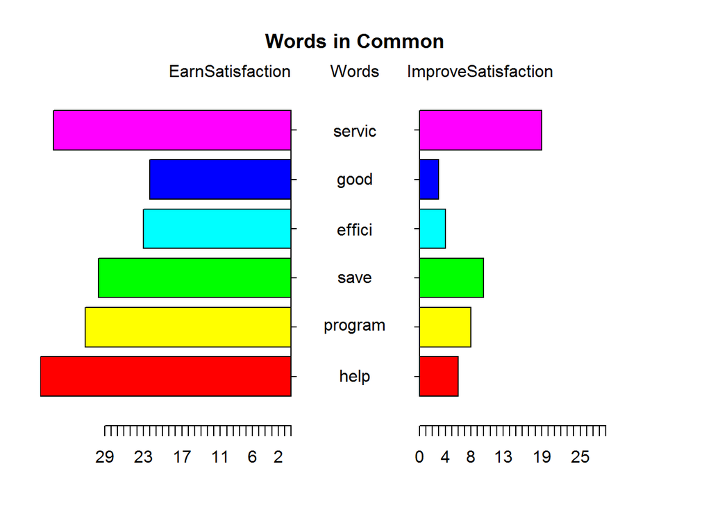

```
## [1] 5.1 4.1 4.1 2.1
```

```r
#Words in Column
top6_df <- data.frame(x = common_words[1:6, 1],
                       y = common_words[1:6, 2],
                       labels = rownames(common_words[1:6, ]))
# Make pyramid plot
pyramid.plot(top6_df$x, top6_df$y,
             labels = top6_df$labels,
             main = "Words in Common",
             gap = 10,
             laxlab = NULL,
             raxlab = NULL,
             unit = NULL, #Can change to % by using "%" instead of NULL
             top.labels = c("EarnSatisfaction",
                            "Words",
                            "ImproveSatisfaction")
             )
```

## Dimension Reduction using Hierarchial Clustering

By Words Clustering, we can visualize which words/group of words are used together based on their frequency distance.

```r
review_tdm_all <- removeSparseTerms(review_tdm_all, sparse = 0.1)
review_tdm_all
```

```
## <<TermDocumentMatrix (terms: 276, documents: 2)>>
## Non-/sparse entries: 552/0
## Sparsity           : 0%
## Maximal term length: 13
## Weighting          : term frequency (tf)
```

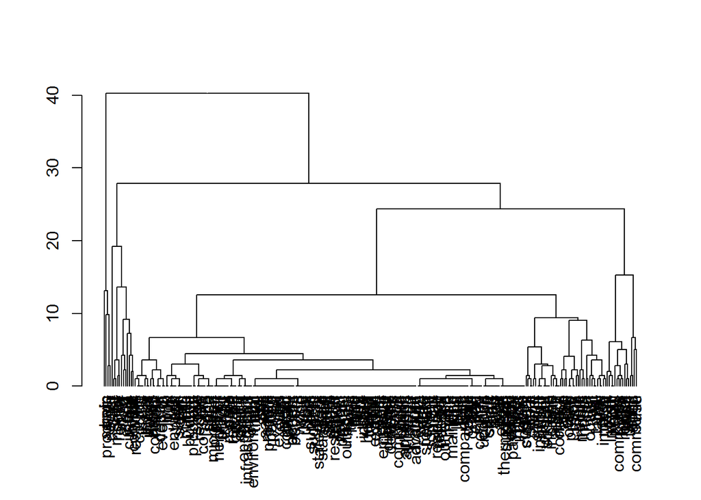

```r
hc <- hclust(d = dist((review_tdm_all), method = "euclidean"), method = "complete") #Replace method to "complete" and see the change in the Dendrogarm appearence along with change in the heights of the tree
# Plot a dendrogram
hcd = as.dendrogram(hc)
plot(hcd)
```

## Zooming in on Dendrograms

As, we can see that the Dendrograms with all the words in both the columns are bit clumsy. Depending on the height of the tree, as we can see that the maximum height of the tree is at 40, so it would be good idea to cut the trees from the Upper and the Lower branch depending on the levels till where we can see and understand the words so used together and visualize a level of correlation between them.

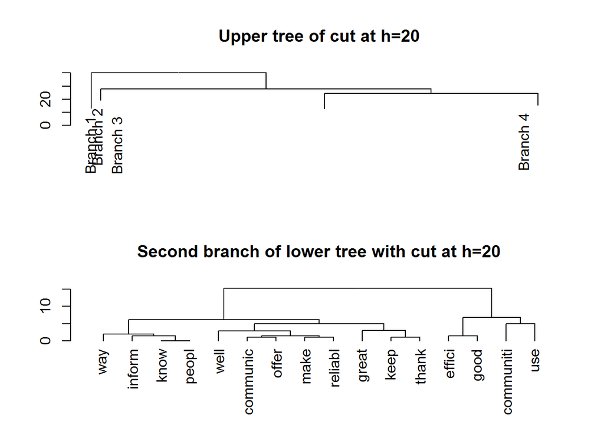

```r
#Plotting Dendrograms with some Cuts
op = par(mfrow = c(2, 1))   #decides the rows at which the visuals will be shown
plot(cut(hcd, h = 20)$upper, main = "Upper tree of cut at h=20")
plot(cut(hcd, h = 20)$lower[[4]], main = "Second branch of lower tree with cut at h=20")
```

### Zooming to the first Dendrogram

Thus, after cutting some of the branches of the trees, it gets more clear on the level of the nodes at the leaf where some of the words can be seen are used together. Such as the words “servic”, “help”, “program”, “save” are used together.

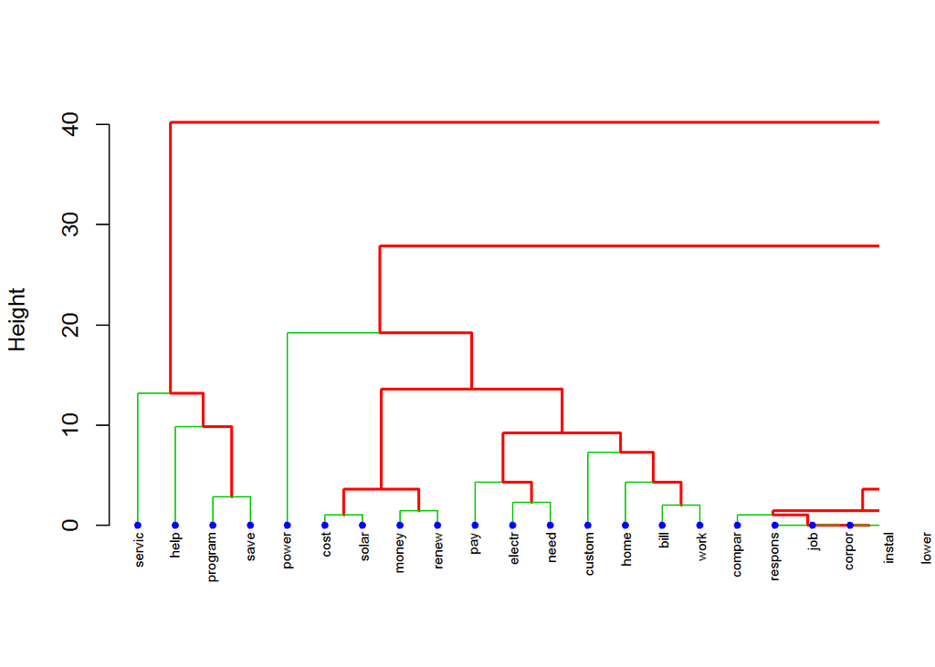

```r
# Zoom in to the first dendrogram
nodePar <- list(lab.cex = 0.6, pch = c(NA, 19),
                cex = 0.7, col = "blue")

plot(hcd, xlim = c(1, 20), ylim = c(1,40), ylab = "Height", nodePar = nodePar,
     edgePar = list(col = 2:3, lwd = 2:1))
```

## Deep Dive

```r
# Sum over all the Columns that indicates the number of Columns, we have 2 questions that we asked so technically we should get 2 as the length
freq <- colSums(as.matrix(review_tdm_all))
length(freq)
```

```
## [1] 2
```

```r
# # Frequency in descending order of terms
ord <- order(freq, decreasing = TRUE)
freq[head(ord)]
```

```
##    1    2
## 1129  896
```

```r
freq[tail(ord)]
```

```
##    1    2
## 1129  896
```

```r
# Finds words that occur 10 times in the entire corpus.
# With increasing value increase the value of lowfreq to 80-100 to check the occurrence of these words 80 times and 100 times respectively within the entire corpus.
findFreqTerms(review_tdm_all, lowfreq = 15)
```

```
##  [1] "bill"      "can"       "communic"  "communiti" "cost"
##  [6] "custom"    "effici"    "electr"    "get"       "good"
## [11] "great"     "help"      "home"      "incom"     "inform"
## [16] "know"      "make"      "money"     "month"     "need"
## [21] "offer"     "outag"     "pay"       "peopl"     "power"
## [26] "program"   "provid"    "reduc"     "reliabl"   "renew"
## [31] "save"      "servic"    "solar"     "time"      "use"
## [36] "way"       "work"
```

## Word Associations

Let’s next check the associations of each word so used in the Corpuses. This helps to identify words that appear together. Higher the correlation limit, higher are these words associations with the word so provideed within the quotations or provided as vectors.

From the results below ot looks like that even at a very low coefficient rate as low as **0.1** the association of the word “help” with all these other words is 1.0, indicating all these words appear together and hence the correlation is 1.

We can play with different words to see how these associations with these different keywords change.

```r
findAssocs(review_tdm_all, c("help","power", "outage"), corlimit=0.1) #change corlimit to see how association changes
```

```
## $help
##      activ       also      alway        app       area     assist
##          1          1          1          1          1          1
##       back     believ     budget       call       care       citi
##          1          1          1          1          1          1
##       come   communic  communiti     compar comparison     condit
##          1          1          1          1          1          1
##    conserv    continu     corpor    current        cut        day
##          1          1          1          1          1          1
##      deliv    detroit     effici     effort     electr    environ
##          1          1          1          1          1          1
##        etc      everi    everyth       good      great       grid
##          1          1          1          1          1          1
##       hous       idea     import       info     inform     instal
##          1          1          1          1          1          1
##     involv        job       keep       know       less      level
##          1          1          1          1          1          1
##      limit       live       long       look        lot      lower
##          1          1          1          1          1          1
##   maintain       make       mani       mean      meter   michigan
##          1          1          1          1          1          1
##       need        new       nice      offer        old      outag
##          1          1          1          1          1          1
##   outreach        pay    payment      peopl    possibl      price
##          1          1          1          1          1          1
##    program     provid     public    qualiti     reason     receiv
##          1          1          1          1          1          1
##      reduc   refriger    reliabl        rep     repair  residenti
##          1          1          1          1          1          1
##    respons      right        run       save        say       seem
##          1          1          1          1          1          1
##       send     servic     someth    sponsor      storm     suppli
##          1          1          1          1          1          1
##    support       take      thank thermostat      think     toward
##          1          1          1          1          1          1
##       tree        tri      updat       usag        use       util
##          1          1          1          1          1          1
##     vehicl       warm        way       well       work       year
##          1          1          1          1          1          1
##
```

[output cut: 21 more lines]

```
##      opportun        option         phone         plant       product
##             1             1             1             1             1
##        promot          rate        recent        regard         renew
##             1             1             1             1             1
##        repres        restor       satisfi        senior          sinc
##             1             1             1             1             1
##         solar         sourc         still       sustain        system
##             1             1             1             1             1
##          tell         thing          time          trim          want
##             1             1             1             1             1
##          wind       without
##             1             1
##
## $outage
## numeric(0)
```

```r
#tm
```

## Bi-Grams

### Top 10 Bi Grams for the 1st Column asking the question:What.does.DTE.do.well.to.earn.your.satisfaction.

```r
review_bigram <- tokens(CustomerReview$EarnSatisfaction) %>%
    tokens_remove("\\p{P}", valuetype = "regex", padding = TRUE) %>% #removes punctuation but leaves empty spaces where these were removed
    tokens_remove(stopwords("english"), padding  = TRUE) %>%
    tokens_ngrams(n = 2) %>%
    dfm()
topfeatures(review_bigram)
```

```
##     energy_efficiency         energy_saving      customer_service
##                    13                     9                     8
## community_involvement           save_energy   efficiency_programs
##                     5                     5                     5
##            low_income              good_job            dte_energy
##                     4                     4                     4
##    efficiency_program
##                     3
```

### Top 10 Bi Grams for the 2nd Column asking the question: What.does.DTE.need.to.improve.other.than.price.to.earn.your.sat.

```r
review_bigram <- tokens(CustomerReview$ImproveSatisfaction) %>%
    tokens_remove("\\p{P}", valuetype = "regex", padding = TRUE) %>% #removes punctuation but leaves empty spaces where these were removed
    tokens_remove(stopwords("english"), padding  = TRUE) %>%
    tokens_ngrams(n = 2) %>%
    dfm()
topfeatures(review_bigram)
```

```
##   renewable_energy         low_income       solar_energy
##                 10                  9                  5
##         wind_power        natural_gas     energy_sources
##                  4                  4                  4
##       energy_costs                $_$ alternative_energy
##                  4                  4                  4
##   customer_service
##                  3
```

## Tri-Grams

```r
review_trigram <- tokens(CustomerReview$EarnSatisfaction) %>%
    tokens_remove("\\p{P}", valuetype = "regex", padding = TRUE) %>% #removes punctuation but leaves empty spaces where these were removed
    tokens_remove(stopwords("english"), padding  = TRUE) %>%
    tokens_ngrams(n = 3) %>%
    dfm()
topfeatures(review_trigram)
```

```
## energy_efficiency_programs            use_less_energy
##                          4                          3
##       customer_service_rep  energy_efficiency_program
##                          3                          2
##          new_electric_plan     good_corporate_citizen
##                          2                          2
##     energy_saving_programs         free_energy_saving
##                          2                          2
##     provides_quality_power responsive_primary_service
##                          1                          1
```

```r
review_trigram <- tokens(CustomerReview$ImproveSatisfaction) %>%
    tokens_remove("\\p{P}", valuetype = "regex", padding = TRUE) %>% #removes punctuation but leaves empty spaces where these were removed
    tokens_remove(stopwords("english"), padding  = TRUE) %>%
    tokens_ngrams(n = 3) %>%
    dfm()
topfeatures(review_trigram)
```

```
##  renewable_energy_options       low_income_families
##                         3                         3
##  renewable_energy_sources       give_better_pricing
##                         2                         2
##                     $_$_$             bill_due_date
##                         2                         2
##    low_income_individuals           home_solar_cost
##                         2                         1
##            power_buy_back electric_vehicle_charging
##                         1                         1
```

## Four-Grams

```r
review_4gram <- tokens(CustomerReview$EarnSatisfaction) %>%
    tokens_remove("\\p{P}", valuetype = "regex", padding = TRUE) %>% #removes punctuation but leaves empty spaces where these were removed
    tokens_remove(stopwords("english"), padding  = TRUE) %>%
    tokens_ngrams(n = 4) %>%
    dfm()
topfeatures(review_4gram)
```

```
## responsive_primary_service_representatives
##                                          1
##                  helo_energy_efficeiny_arr
##                                          1
##                 energy_efficeiny_arr_great
##                                          1
##          using_energy_efficient_appliances
##                                          1
##                well_run_company_interested
##                                          1
##                     every_aspect_dte_seems
##                                          1
##               customer_service_rep_helping
##                                          1
##               making_energy_saving_options
##                                          1
##            energy_saving_options_available
##                                          1
##     continuosly_embarrassing_energy_saving
##                                          1
```

```r
review_4gram <- tokens(CustomerReview$ImproveSatisfaction) %>%
    tokens_remove("\\p{P}", valuetype = "regex", padding = TRUE) %>% #removes punctuation but leaves empty spaces where these were removed
    tokens_remove(stopwords("english"), padding  = TRUE) %>%
    tokens_ngrams(n = 4) %>%
    dfm()
topfeatures(review_4gram)
```

```
## electric_vehicle_charging_stations   senior_citizens_without_pensions
##                                  1                                  1
##       stop_sending_notices_telling            like_toronto_paying_300
##                                  1                                  1
##            man_made_global_warming      developed_high_blood_pressure
##                                  1                                  1
##              old_analog_meter_back        keep_improving_service_even
##                                  1                                  1
##      excessive_power_usage_letters      improving_service_even_though
##                                  1                                  1
```